##### [Centro di Referenza Nazionale per l’Epidemiologia, l’Informazione e l’Analisi del Rischio](http://www.izs.it/IZS/Attivita_Nazionali/Centri_di_Referenza_Nazionale/CRN_-_Covepi)

*T-Racing Report generato il 2023-10-25 08:05:01*

# 1 Criteri di ricerca impostati

- Periodo selezionato: 2023-05-01 / 2024-04-30 (365 giorni)
- Specie incluse: SUINI
- Movimenti al macello: INCLUSI
- Movimenti da e verso estero: ESCLUSI
- Aggregazione geografica dell’azienda: NO
- Livelli a priori: 5
- Direzione della ricerca: AVANTI
- Seed: 190PV004 - 190PV008 - 113PV001

Il network selezionato consta di 123885 movimenti e 36186 nodi

Il rintraccio è fatto di:

62 movimenti;

20 nodi;

3 livelli;

171 giorni.

# 2 Risultato del rintraccio <sup><sup>Nota</sup></sup>

Caratteristiche del network risultante:

- Nodi: 20
- Link: 62
- Numero di animali coinvolti: 36493
- Livelli (max): 3
- Arco temporale movimenti: 2023-05-01 / 2023-10-19 (171 giorni)

Tabella degree e strength dei Seed:

| CODICE | Degree | NCapi |
| --- | --- | --- |
| 190PV008 | 5 | 1003 |
| 190PV004 | 5 | 475 |
| 113PV001 | 22 | 17686 |

## 2.1 Grafo interattivo

Il grafo può essere ingrandito o rimpicciolito (scroll del mouse), i nodi e i link contengono le informazioni principali su over del mouse

[interactive chart not shown]

## 2.2 Mappa interattiva

La mappa può essere ingrandita o rimpicciolita (scroll del mouse), i nodi e i link contengono le informazioni principali su over/click del mouse. Sono disponibili i differenti layer utilizzati (focolai e/o genetico oltre che link e nodi del network trovato) e basi cartografiche.

[interactive chart not shown]

## 2.3 Legenda

### 2.3.1 Nodi

I nodi del network visualizzati sul grafo possono essere tematizzati dall’utente utilizzando il tipo di struttura (forma) e attività produttiva (colore) come mostrato in figura. I nodi possono essere temeatizzati anche in base alla disponibilità di coordinate geografiche (valide o rappresentate dal centroide del comune); in questo caso la tematizzazione mostrata sul grafo coincide con quella mostrata sulla mappa.

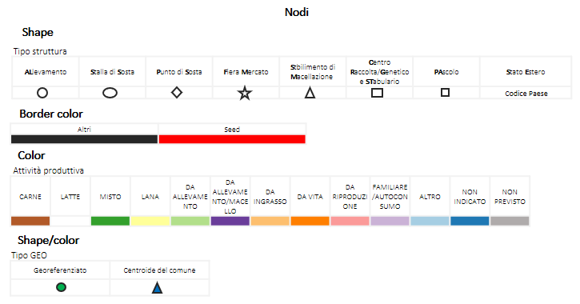

*Nella legenda sono stati evidenziati in grassetto gli acronimi utilizzati per definire i tipi di struttura così come riportati in BDN.*

### 2.3.2 Archi

Lo spessore dei movimenti riflette il numero di animali che transitano. Il colore può rappresentare i livelli del network e il tempo. In questi casi la scala del rosso è stata implementata. Q seconda del livello di aggregazione impostato il colore può riflettere anche la specie o il tipo di struttura e produzione del nodo raggiunto o di origine, secondo la figura seguente.

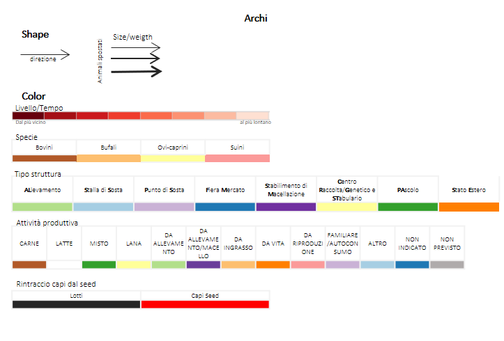

# 3 Tabelle dati

Seguono le tabelle dati di movimenti, nodi e matricole degli animali collegati al seed (se effettuata una ricerca per capi singoli)  
(le medesime tabelle possono essere scaricate in formato excel dall’applicazione).

## 3.1 Nodi

| Azienda | Istat | Tipo | Orientamento | Focolaio |
| --- | --- | --- | --- | --- |
| 010BG013 | 16010 | AL | PRODUZIONE DA INGRASSO | False |
| 010BG022 | 16010 | AL | PRODUZIONE DA INGRASSO | False |
| 014BS033 | 17014 | AL | PRODUZIONE DA INGRASSO | False |
| 026MN008 | 20026 | AL | PRODUZIONE DA INGRASSO | False |
| 030-2037M | 19087 | SM |  | False |
| 030-2097M | 98002 | SM |  | False |
| 030-523M | 19062 | SM |  | False |
| 030-544M | 20066 | SM |  | False |
| 050-773M | 23040 | SM |  | False |
| 051MN051 | 20051 | AL | PRODUZIONE DA INGRASSO | False |

[output cut: 10 more lines]

## 3.2 Focolai

Peste Suina Africana

| CODICE | PROVINCIA | COMUNE | TIPO | STATO | SOSPETTO | CONFERMA | ESTINZIONE | SPECIE | SIEROTIPO |
| --- | --- | --- | --- | --- | --- | --- | --- | --- | --- |
| AL40754G | GE | ROVEGNO | POSITIVITA' DIAGNOSTICA | C | 2023-10-11 | 2023-10-13 |  | CINGHIALI |  |
| AL40767G | GE | SERRA RICCO\' | POSITIVITA' DIAGNOSTICA | C | 2023-10-09 | 2023-10-12 |  | CINGHIALI |  |
| AL40819G | GE | BARGAGLI | POSITIVITA' DIAGNOSTICA | C | 2023-10-19 | 2023-10-19 |  | CINGHIALI |  |
| AL38841G | AL | STAZZANO | FOCOLAIO CLINICO | C | 2023-05-13 | 2023-05-16 |  | CINGHIALI |  |
| AL38885G | SV | VARAZZE | POSITIVITA' DIAGNOSTICA | C | 2023-05-10 | 2023-05-15 |  | CINGHIALI |  |
| AL38941G | SA | SANZA | POSITIVITA' DIAGNOSTICA | C | 2023-05-22 | 2023-05-22 |  | CINGHIALI |  |
| AL39042G | SV | STELLA | POSITIVITA' DIAGNOSTICA | C | 2023-05-28 | 2023-05-31 |  | CINGHIALI |  |
| AL38678G | SV | GIUSVALLA | POSITIVITA' DIAGNOSTICA | C | 2023-05-01 | 2023-05-05 |  | CINGHIALI |  |
| AL38794G | RC | REGGIO DI CALABRIA | POSITIVITA' DIAGNOSTICA | C | 2023-05-08 | 2023-05-12 |  | CINGHIALI |  |
| AL39408G | GE | DAVAGNA | POSITIVITA' DIAGNOSTICA | C | 2023-06-19 | 2023-06-21 |  | CINGHIALI |  |

[output cut: 378 more lines]

## 3.3 Movimenti

| AziendaOrigine | TipoOrigine | OrientamentoOrigine | AziendaDestinazione | TipoDestinazione | OrientamentoDestinazione | Data | Capi | Livello | Specie |
| --- | --- | --- | --- | --- | --- | --- | --- | --- | --- |
| 026MN008 | AL | PRODUZIONE DA INGRASSO | 053MN002 | AL | PRODUZIONE DA INGRASSO | 2023-05-04 | 1350 | 2 | SUINI |
| 190PV008 | AL | PRODUZIONE DA INGRASSO | 080-207M | SM |  | 2023-05-04 | 128 | 1 | SUINI |
| 010BG022 | AL | PRODUZIONE DA INGRASSO | 080-207M | SM |  | 2023-09-06 | 166 | 3 | SUINI |
| 026MN008 | AL | PRODUZIONE DA INGRASSO | 010BG013 | AL | PRODUZIONE DA INGRASSO | 2023-07-18 | 680 | 2 | SUINI |
| 063PV002 | AL | PRODUZIONE DA INGRASSO | 050-773M | SM |  | 2023-08-05 | 27 | 3 | SUINI |
| 010BG022 | AL | PRODUZIONE DA INGRASSO | 030-2037M | SM |  | 2023-09-06 | 17 | 3 | SUINI |
| 010BG022 | AL | PRODUZIONE DA INGRASSO | 030-523M | SM |  | 2023-09-06 | 260 | 3 | SUINI |
| 010BG022 | AL | PRODUZIONE DA INGRASSO | 080-207M | SM |  | 2023-09-01 | 128 | 3 | SUINI |
| 113PV001 | AL | DA RIPRODUZIONE | 026MN008 | AL | PRODUZIONE DA INGRASSO | 2023-07-31 | 837 | 1 | SUINI |
| 113PV001 | AL | DA RIPRODUZIONE | 030-2097M | SM |  | 2023-07-31 | 47 | 1 | SUINI |

[output cut: 52 more lines]

# 4 Fonti dati

- BDN  
  L’applicazione consente il rintraccio degli spostamenti di animali relativamente agli ultimi 7 anni di dati registrati in BDN.  
  NB: I dati possono subire variazioni nel tempo a causa di aggiornamenti costanti (anche di dati pregressi)
- SIMAN
- GENPAT

# 5 Note

## 5.1 Riproducibilità dei risultati

Data la natura di gestione del network implementata, che prevede la modifica iterativa e personalizzata da parte dell’utente (rimozione di link e nodi di scarso interesse a vari step), il risultato finale del rintraccio non è sempre riproducibile. Fanno eccezione:

- i rintracci condotti sulla rete per singoli capi, anche se iterato;
- il risultato ottenuto senza passaggi di iterazioni per livelli di profondità (nei quali casi, a partire dalle informazioni contenute nella sezione 1. Criteri di ricerca impostati, il risultto finale è riproducibile fermo restando il dato proveniente dai vari sistemi informativi - vedi sezione Fonti dati)

##### [Centro di Referenza Nazionale per l’Epidemiologia, l’Informazione e l’Analisi del Rischio](http://www.izs.it/IZS/Attivita_Nazionali/Centri_di_Referenza_Nazionale/CRN_-_Covepi)